# Prediction Assignment Writeup

Alexander Seifert

This project builds a machine learning algorithm to predict activity quality from activity monitors. By creating a [random forest](https://en.wikipedia.org/wiki/Random_forest) we achieve an accuracy of `0.991` (out of sample error `0.009`) on the validation set (60/40 split) and `100%` accuracy on the test set.

## Introduction

In this project, we will use data from accelerometers on the belt, forearm, arm, and dumbell of 6 test participants. They were asked to perform barbell lifts correctly and incorrectly in 5 different ways:

- exactly according to the specification (Class A)
- throwing the elbows to the front (Class B)
- lifting the dumbbell only halfway (Class C)
- lowering the dumbbell only halfway (Class D) and
- throwing the hips to the front (Class E)

(More information on the study that collected the data is available on the Groupware@LES [Human Activity Recognition project website](http://groupware.les.inf.puc-rio.br/har#ixzz34oK3Rck9).)

We will try to predict from the sensory data the way in which the exercise was performed (i.e. class A to E).

## Data Preprocessing

First we set the seed, so our analysis is reproducible. We then load the training and testing data. Some of the data contained “#DIV/0!” entries, which most likely came from an illegal division by 0. We treat those as NAs.

```r
set.seed(42)
library(caret)
training.raw = read.csv("pml-training.csv", na.strings = c("", "NA", "#DIV/0!"))
testing.raw  = read.csv("pml-testing.csv", na.strings = c("", "NA", "#DIV/0!"))
```

As a next step, we remove near zero variance predictors.

```r
nzv  = nearZeroVar(training.raw, saveMetrics=TRUE)
omit = which(nzv$nzv==TRUE)
training.new = training.raw[,-omit]
```

Let’s weed out the NA heavy colums

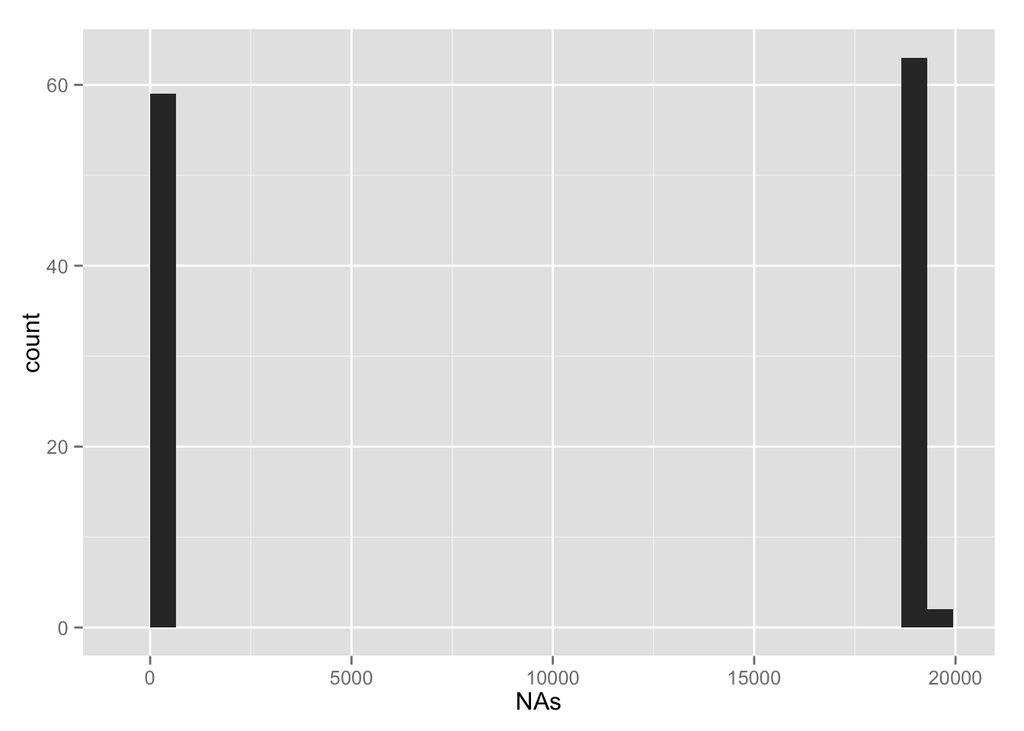

```r
NAs = apply(training.new, 2, function(x) { sum(is.na(x)) })
qplot(NAs, binwidth = max(NAs)/30)
```

```r
good.cols = names(NAs[NAs == 0])
```

From the remaining variables, we keep only those coming from sensory input:

```r
predictors = grep("(_belt|_arm|_dumbbell|_forearm)", good.cols, value=T)
```

Now we create a new training set with only the predictors and the output (`classe`)

```r
training.new = cbind(training.new[,c(predictors, "classe")])
```

Having done these steps, we can move on to model creation.

## Model Creation

First, we create a 60/40 data split for training/validation set:

```r
intrain  = createDataPartition(training.new$classe, p = 0.6, list = FALSE)
training = training.new[intrain,]
validate = training.new[-intrain,]
```

Now we can train our model. We will use 4-fold cross validation and fit a random forest to the training set.

```r
trc = trainControl(method = "cv", number = 4, allowParallel=T)
rf.fit = train(classe ~ .,
               data = training,
               method = "rf",
               trControl = trc)
```

## Model Evaluation

Finally, we can use our validation set to evaluate our model along different dimensions:

```r
rf.pred = predict(rf.fit, validate)
confusionMatrix(rf.pred, validate$classe)
```

```
## Confusion Matrix and Statistics
##
##           Reference
## Prediction    A    B    C    D    E
##          A 2231    8    0    0    0
##          B    1 1506   14    0    0
##          C    0    4 1350   29    0
##          D    0    0    4 1256    7
##          E    0    0    0    1 1435
##
## Overall Statistics
##
##                Accuracy : 0.991
##                  95% CI : (0.989, 0.993)
##     No Information Rate : 0.284
##     P-Value [Acc > NIR] : <2e-16
##
##                   Kappa : 0.989
##  Mcnemar's Test P-Value : NA
##
## Statistics by Class:
##
##                      Class: A Class: B Class: C Class: D Class: E
## Sensitivity             1.000    0.992    0.987    0.977    0.995
## Specificity             0.999    0.998    0.995    0.998    1.000
## Pos Pred Value          0.996    0.990    0.976    0.991    0.999
## Neg Pred Value          1.000    0.998    0.997    0.995    0.999
## Prevalence              0.284    0.193    0.174    0.164    0.184
## Detection Rate          0.284    0.192    0.172    0.160    0.183
## Detection Prevalence    0.285    0.194    0.176    0.161    0.183
## Balanced Accuracy       0.999    0.995    0.991    0.987    0.997
```

With the accuracy being `0.991` we get an out of sample error of `1 - 0.991 = 0.009`.

## Test Output

We predict the test answers

```r
testing = testing.raw[, names(training)[-53]]
answers = predict(rf.fit, testing)

answers
```

```
##  [1] B A B A A E D B A A B C B A E E A B B B
## Levels: A B C D E
```

… and write those answers to disk:

```r
pml_write_files = function(x){
        n = length(x)
        for(i in 1:n){
                filename = paste0("problem_id_",i,".txt")
                write.table(x[i],file=filename,quote=FALSE,row.names=FALSE,col.names=FALSE)
        }
}
pml_write_files(answers)
```